# INFO550HW4

Zhen Wu

11/5/2021

## Summary of Descriptive Statistcs

|  | Benign Breast Cancer (N=357) | Malignant Breast cancer (N=212) | P-value |
| --- | --- | --- | --- |
| Mean of Cancer Radius |  |  |  |
| Mean (SD) | 12.1 (1.78) | 17.5 (3.20) | <0.001 |
| Median [Min, Max] | 12.2 [6.98, 17.9] | 17.3 [11.0, 28.1] |  |
| Mean of Cancer Texture |  |  |  |
| Mean (SD) | 17.9 (4.00) | 21.6 (3.78) | <0.001 |
| Median [Min, Max] | 17.4 [9.71, 33.8] | 21.5 [10.4, 39.3] |  |
| Mean of Cancer Perimeter |  |  |  |
| Mean (SD) | 78.1 (11.8) | 115 (21.9) | <0.001 |
| Median [Min, Max] | 78.2 [43.8, 115] | 114 [71.9, 189] |  |
| Mean of Cancer Area |  |  |  |
| Mean (SD) | 463 (134) | 978 (368) | <0.001 |
| Median [Min, Max] | 458 [144, 992] | 932 [362, 2500] |  |
| Mean of Cancer Smoothness |  |  |  |
| Mean (SD) | 0.0925 (0.0134) | 0.103 (0.0126) | <0.001 |
| Median [Min, Max] | 0.0908 [0.0526, 0.163] | 0.102 [0.0737, 0.145] |  |
| Mean of Cancer Compactness |  |  |  |
| Mean (SD) | 0.0801 (0.0337) | 0.145 (0.0540) | <0.001 |
| Median [Min, Max] | 0.0753 [0.0194, 0.224] | 0.132 [0.0461, 0.345] |  |
| Mean of Cancer Concavity |  |  |  |
| Mean (SD) | 0.0461 (0.0434) | 0.161 (0.0750) | <0.001 |
| Median [Min, Max] | 0.0371 [0, 0.411] | 0.151 [0.0240, 0.427] |  |
| Mean of Cancer Concave Points |  |  |  |
| Mean (SD) | 0.0257 (0.0159) | 0.0880 (0.0344) | <0.001 |
| Median [Min, Max] | 0.0234 [0, 0.0853] | 0.0863 [0.0203, 0.201] |  |
| Mean of Cancer Symmetry |  |  |  |
| Mean (SD) | 0.174 (0.0248) | 0.193 (0.0276) | <0.001 |
| Median [Min, Max] | 0.171 [0.106, 0.274] | 0.190 [0.131, 0.304] |  |
| Mean of Cancer Fractal Dimension |  |  |  |
| Mean (SD) | 0.0629 (0.00675) | 0.0627 (0.00757) | 0.767 |
| Median [Min, Max] | 0.0615 [0.0519, 0.0958] | 0.0616 [0.0500, 0.0974] |  |

569 subjects included in the study. 357 subjects were diagnosed as benign breast cancer while 212subjects were diagnosed as malignant breast cancer. The radius mean of breast cancer among all subjects was 14.13. The perimeter mean of breast cancer among all subjects was 91.97.The texture mean of breast cancer among subjects was 19.29.The area mean of breast cancer among subjects was 654.89. The radius mean and perimeter mean of breast cancer among benign group were statistically smaller than that among malignant group by t-test. It showed that radius and perimeter of breast cancer were two characteristics of malignant breast cancer.

## Assess the association between concavity mean and compactness mean

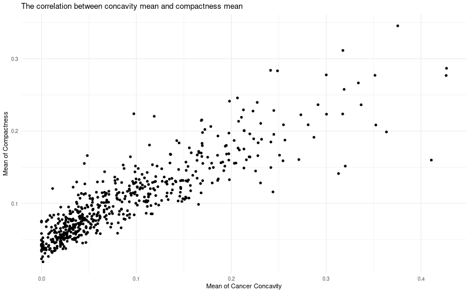

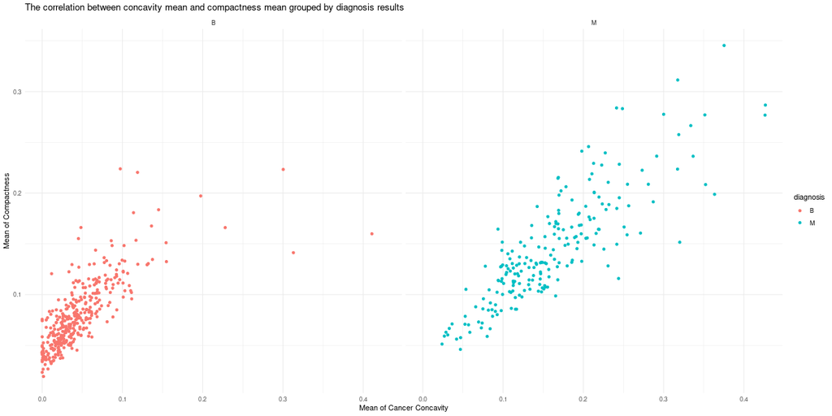